# biogram: N-Gram Analysis of Biological Sequences

25.01.2015

## Introduction

Aim: facilitate n-gram analysis of biological sequences by reducing the dimensionality of the problem through:

- filtering features,
- reducing amino acid alphabet.

## n-grams

n-grams: continuous or discontinuous sub-sequences of nucleic or protein sequences.

Applications:

- determining the family of genomes to which a given genome belongs (Tomović, Janicić, and Keselj 2006).

## Reduction of alphabets

Features related to the 3d structure of proteins:

- protein folding (Murphy, Wallqvist, and Levy 2000),
- prediction of protein interactions (Launay et al. 2007).

## Methods

- QuiPT (Fisher exact test, indefinitely faster, multiple criterions),
- normalized encoding distance (heuristic to find the best reduced alphabets).

## QuiPT

**Qui**ck **P**ermutation **T**est is a fast solution for filtering a large number of binary features provided that target vector is also binary. It is typical case for positioned n-gram data. Moreover, even considering unpositioned n-grams, if the \(n\) is sufficiently high, the matrix of counts is almost sparse and little to no information is lost after data is artifically binarized.

## QuiPT

QuiPT uses criterions which measure how imbalanced is a contingency table.

In our application, analysis of n-grams, we are interested in Bernoulli r.v. Let us consider the contingency table we get:

| target\feature | 1 | 0 |
| --- | --- | --- |
| 1 | \(n_{1,1}\) | \(n_{1,0}\) |
| 0 | \(n_{0,1}\) | \(n_{0,0}\) |

## QuiPT

If probability that target equals 1 is \(p\) and probability that feature equals 1 is \(q\) and feature and target are independant then each of them has the following probabilities \[P((Target, Feature) = (1,1)) = p \cdot q\] \[P((Target, Feature) = (1,0)) = p \cdot (1-q)\] \[P((Target, Feature) = (0,1)) = (1-p) \cdot q\] \[P((Target, Feature) = (0,0)) = (1-p) \cdot (1-q)\]

This means that a target-feature can be described as multinomial distribution.

## QuiPT

Considering all above, we are able to compute exact probability of obtaining a specific confusion matrix depending on the \(n_{1,1}\).

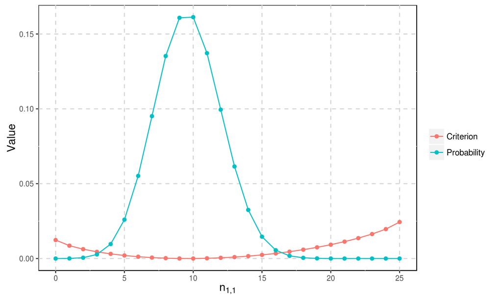

## Encoding distance

The encoding distance, as computed per the *calc_ed* function, between **a** and **b** is defined as the minimum number of amino acids that have to be moved between subgroups of encoding to make **a** identical to **b** (the order of subgroups in the encoding and amino acids in a group is unimportant).

## Encoding distance

The encoding distance may be further normalized by a factor reflecting how much moving amino acids between groups altered mean group properties.

## Encoding A

Encoding A

| ID | Groups |
| --- | --- |
| 1 | P |
| 2 | F, I, W, Y |
| 3 | A, C, D, E, G, H, K, L, M, N, Q, R, S, T, V |

## Encoding B

Encoding B

| ID | Groups |
| --- | --- |
| 1 | F, R, W, Y |
| 2 | C, I, L, T, V |
| 3 | A, D, E, G, H, K, M, N, P, Q, S |

The encoding distance between both encodings is 7.

## Normalized encoding distance

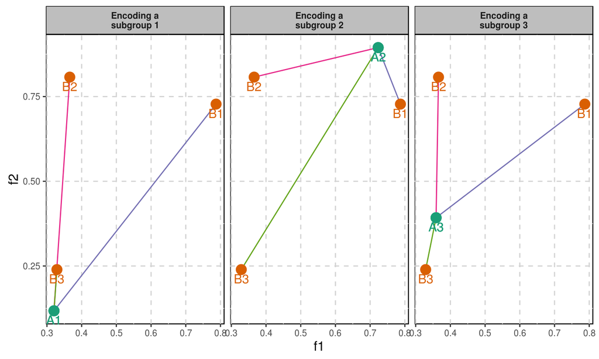

## Normalized encoding distance

The figure above represents the distances between groups of encoding **a** (green dots) and groups of encoding **b** (red dots). The position of the dot defined by mean values of specific properties of all amino acids belonging to the group.

## Normalized encoding distance

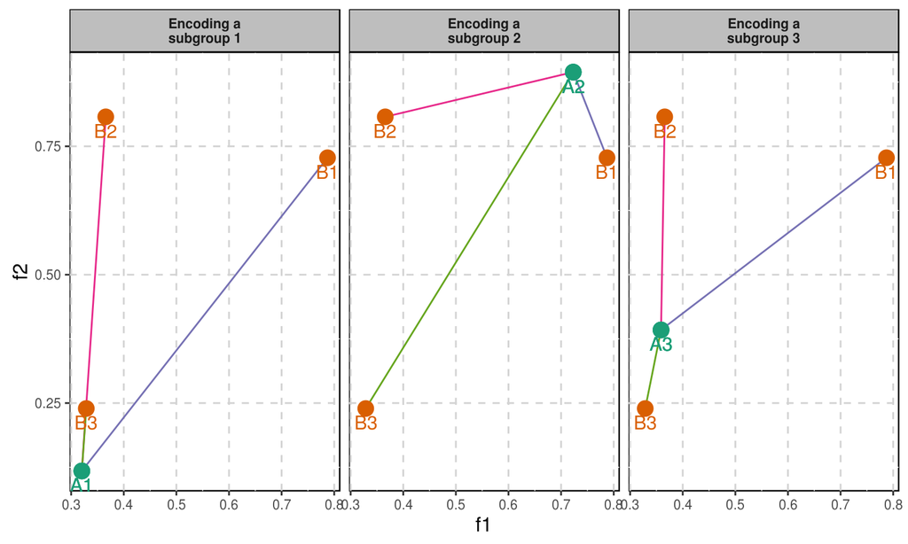

## Normalized encoding distance

|  | Enc a, group 1 | Enc a, group 2 | Enc a, group 3 |
| --- | --- | --- | --- |
| Enc b, group 1 | 0.7681436 | 0.1786769 | 0.5441119 |
| Enc b, group 2 | 0.6910472 | 0.3677947 | 0.4150182 |
| Enc b, group 3 | 0.1219397 | 0.7645517 | 0.1558620 |

For each group in encoding **a**, we choose the minimum distance \(d_i\) between the group and any group belonging to the encoding **b**. The normalization factor is equal to the sum of minimum distances for each group in **a**.

\[ n_f = \sum_{i \in 1, 2, 3} \min \left( d_i \right) \]

In the case depicted above, \(n_f\) is equal to the sum of 0.1219, 0.1787, 0.1559: 0.4565.

## Results

Classification n-grams typical for various mitochondrial genomes.

Phy-Mer: a mitochondrial genome haplogroup-defining algorithm using a k-mer approach, useable also for NGS data (Navarro-Gomez et al. 2015)

- long sequences of nucleotides of uneven length;
- multiple classification problem.

## Results

Recognizing features in epitopes (Koch et al. 2013):

- amino acid sequences,
- equally long peptides (may use position information),
- 8 residues,
- only two categories.

## References

Koch, Christian P., Anna M. Perna, Max Pillong, Nickolay K. Todoroff, Paul Wrede, Gerd Folkers, Jan A. Hiss, and Gisbert Schneider. 2013. “Scrutinizing MHC-I Binding Peptides and Their Limits of Variation.” *PLoS Computational Biology* 9 (6): e1003088. doi:10.1371/journal.pcbi.1003088.

Launay, Guillaume, Raul Mendez, Shoshana Wodak, and Thomas Simonson. 2007. “Recognizing Protein–protein Interfaces with Empirical Potentials and Reduced Amino Acid Alphabets.” *BMC Bioinformatics* 8: 270. doi:10.1186/1471-2105-8-270.

Murphy, Lynne Reed, Anders Wallqvist, and Ronald M. Levy. 2000. “Simplified Amino Acid Alphabets for Protein Fold Recognition and Implications for Folding.” *Protein Engineering* 13 (3): 149–52. doi:10.1093/protein/13.3.149.

Navarro-Gomez, Daniel, Jeremy Leipzig, Lishuang Shen, Marie Lott, Alphons P. M. Stassen, Douglas C. Wallace, Janey L. Wiggs, Marni J. Falk, Mannis van Oven, and Xiaowu Gai. 2015. “Phy-Mer: A Novel Alignment-Free and Reference-Independent Mitochondrial Haplogroup Classifier.” *Bioinformatics (Oxford, England)* 31 (8): 1310–12. doi:10.1093/bioinformatics/btu825.

Tomović, Andrija, Predrag Janicić, and Vlado Keselj. 2006. “N-Gram-Based Classification and Unsupervised Hierarchical Clustering of Genome Sequences.” *Computer Methods and Programs in Biomedicine* 81 (2): 137–53. doi:10.1016/j.cmpb.2005.11.007.